# Credit Card Payoff Calculator Using Shiny

Vijay Ramanujam  
February 23, 2018

### Introduction

Credit card issuers are required to collect payments that pays down a borrower's principal over a reasonable period of time. Most issuers charge 1% of the principal amount, plus the monthly interest, plus any fees. There are a lot of online calculators that give you fixed payment amount every month once you specify the number of months to payoff the debt.

This Shiny app calculator differs from the above by giving you the absolute minimum payment amount needed to avoid any penalty by the card issuer, and the number of months needed to payoff the balance by fulfilling the issuer's conditions. This will be handy for people that can't guarantee to pay a fixed amount for a fixed number of months.

### Information Required

The formula to calculate the monthly minimum payment - **p*(i/12/100) + p*(m/100) + a**

### Payoff Table

Some part of the code is hidden, since the monthly payment calculation logic is over 50 lines.

```r
nPrincipal <- 5000 #(p)
nInterest <- 7.99 #(i)
sMinimum <- 1 #(m)
nFixed <- 25
nAdditional <- 20 #(a)
aTable <- NULL
```

```r
head(as.data.frame(aTable))
```

```
  Month Payment Principal Interest Principal.Paid Interest.Paid
1     1  103.29     70.00    33.29          70.00         33.29
2     2  102.13     69.30    32.83         139.30         66.12
3     3  100.97     68.61    32.36         207.91         98.48
4     4   99.83     67.92    31.91         275.83        130.39
5     5   98.70     67.24    31.46         343.07        161.85
6     6   97.58     66.57    31.01         409.64        192.86
  Remaining.Balance
1           4930.00
2           4860.70
3           4792.09
4           4724.17
5           4656.93
6           4590.36
```

### Shiny App Screenshot

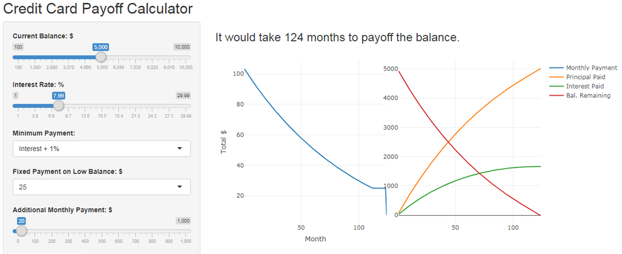

Shiny app hosted at https://vxrds.shinyapps.io/CCPayoffCalculator

All source code and supporting documentation located at https://github.com/vxrds/vxrds.github.io/tree/master/JHU%20-%20Data%20Science/09_DevelopingDataProducts/Week4